# Presentation for Coursera Data Science Capstone

Mark Davey  
February 4th 2018

### Problem

Three keys for a successful application are:

- Speed (The answer needs to be almost instantaneously to be useful)
- Correct answer (The words and the probability need to make sense)
- Visualization (Though the problem asked for only one word. The Ngram created an ordered result set that suited a word cloud plot)

### The key to this project is the NGRAM dataset

The importance of the Ngram data-set is key to the success of the application

- It needs to be small enough that it can load into memory in a few seconds (two or less).
- It needs to be less than 5MB in size since this is the maximum default for shiny application.
- It needs to be comprehensive enough that it is useful about 900,000. So I limited it to top seven results for each n-gram and the response word must have at least three examples in the data set.
- It needs to have offensive words and non ascii words removed since the source material is English.
- The use of data.table with setkey improves searches to about a second giving reasonable response time.
- The response needs to be ordered by how appropriate the suggestion is based on counts in training materials.

### Algorithm used to make the prediction

- Algorithm used:
  - Modified BackOff which used a NGRAM the first three words used to look up the fourth for the suggestion.
- Added fall back to previous words:
  - If first three words could not find a match, the I ignored the last word and looked at the previous word
- A last chance data set
  - If the algorithm fails then I created a backup result set with the most common words
- No need for two and three Ngram
  - I realized if the summed the data and made the results unique I need not build two and three Ngram saving memory and time.

### Using the Application

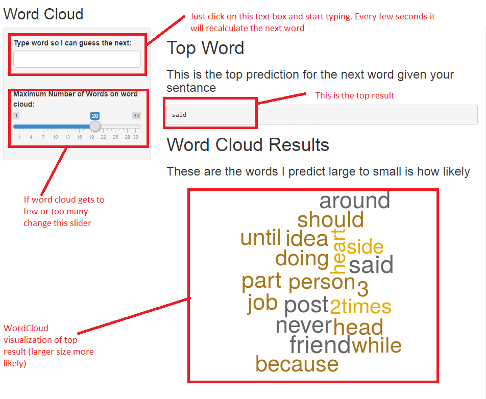

- Using Reactive Shiny text box means it updates as you type
- Review the top word text box
- Review the word cloud for multiple words

### References

- Primary reference: https://www.tidytextmining.com/tidytext.html
- Application: https://kariato.shinyapps.io/NextWordCloud/
- Presnetation: http://rpubs.com/kariato/355944
- GitHub: https://github.com/kariato/Coursera-Data-Science-Capstone